# APS1 — Análise Exploratória de Dados: Adult Income Census

**Disciplina:** Machine Learning  
**Integrantes:** Vanessa Ricoy e Victor Cunha  
**Data de entrega:** 14/09/2026

## Objetivo

Queremos investigar como idade, escolaridade e ocupação se relacionam com as duas faixas de renda do Adult Income Census. Antes de pensar em um classificador, vamos conferir os problemas da base e comparar os grupos nos gráficos. Ao final, organizamos o pré-processamento para a próxima etapa do projeto. O alvo é `income`: renda anual de até 50 mil dólares (`<=50K`) ou acima desse valor (`>50K`).

```python
import kagglehub
import glob
import os
import pandas as pd
import matplotlib.pyplot as plt
import seaborn as sns

# Download do dataset diretamente do Kaggle
pasta_dataset = kagglehub.dataset_download(
    "anaghakp/adult-income-census"
)

arquivo_csv = glob.glob(
    os.path.join(pasta_dataset, "*.csv")
)[0]

df = pd.read_csv(arquivo_csv)
```

```
Using Colab cache for faster access to the 'adult-income-census' dataset.
```

```python
sns.set_theme(
    style="whitegrid",
    context="notebook",
    font_scale=1.05
)

COR_PRINCIPAL = "#9E2A2B"   # vermelho
COR_SECUNDARIA = "#C65D47"  # marromzin
COR_DESTAQUE = "#5F0F40"    # vinho
COR_NEUTRA = "#6C757D"      # cinza


print("Dimensões do dataset:", df.shape)
display(df.head())
```

```
Dimensões do dataset: (31947, 12)
```

|  | age | workclass | fnlwgt | education | education.num | marital.status | occupation | relationship | race | sex | native.country | income |
| --- | --- | --- | --- | --- | --- | --- | --- | --- | --- | --- | --- | --- |
| 0 | 17 | Private | 148522 | 11th | 7 | Never-married | occupation | Own-child | White | Male | United-States | <=50K |
| 1 | 17 | Private | 93235 | 12th | 8 | Never-married | occupation | Own-child | White | Female | United-States | <=50K |
| 2 | 17 | Private | 184924 | 9th | 5 | Never-married | occupation | Own-child | White | Male | United-States | <=50K |
| 3 | 17 | Private | 116626 | 11th | 7 | Never-married | occupation | Own-child | White | Male | United-States | <=50K |
| 4 | 17 | Private | 209949 | 11th | 7 | Never-married | occupation | Own-child | White | Female | United-States | <=50K |

```python
tipos_variaveis = pd.DataFrame({
    "Tipo no Pandas": df.dtypes,
    "Tipo para análise": [
        "Numérica" if coluna in ["age", "fnlwgt", "education.num"]
        else "Categórica"
        for coluna in df.columns
    ]
})

display(tipos_variaveis)
```

[output not shown]

## 1. Conhecendo o dataset

O arquivo usado nas análises tem 31.947 linhas e 12 colunas. A renda já vem dividida em duas categorias, então a tarefa futura será de classificação, sem prever um valor exato em dólares.

As colunas descrevem:

- `age`: idade;
- `workclass`: tipo de vínculo ou setor de trabalho;
- `fnlwgt`: peso amostral do censo, relacionado à representação de cada registro na população;
- `education` e `education.num`: escolaridade em categorias e sua codificação ordenada;
- `marital.status`: estado civil;
- `occupation`: ocupação profissional;
- `relationship`: relação familiar registrada;
- `race`: categoria de raça registrada;
- `sex`: sexo registrado;
- `native.country`: país de origem;
- `income`: faixa de renda, nossa variável-alvo.

Idade, peso amostral e código de escolaridade aparecem como números, mas têm significados diferentes. Em especial, `education.num` indica níveis ordenados: uma diferença de um ponto não deve ser lida automaticamente como um ano adicional de estudo. A primeira checagem abaixo procura ausências, categorias suspeitas e linhas repetidas.

```python
# Contagem de valores potencialmente inconsistentes
inconsistencias = pd.DataFrame({
    "Valores '?'": (df == "?").sum(),
    "Texto 'occupation'": (df == "occupation").sum(),
    "Valores ausentes": df.isna().sum()
})

inconsistencias["Total identificado"] = inconsistencias.sum(axis=1)
display(inconsistencias)

print("Linhas duplicadas:", df.duplicated().sum())
```

|  | Valores '?' | Texto 'occupation' | Valores ausentes | Total identificado |
| --- | --- | --- | --- | --- |
| age | 0 | 0 | 0 | 0 |
| workclass | 1778 | 0 | 0 | 1778 |
| fnlwgt | 0 | 0 | 0 | 0 |
| education | 0 | 0 | 0 | 0 |
| education.num | 0 | 0 | 0 | 0 |
| marital.status | 0 | 0 | 0 | 0 |
| occupation | 1785 | 1462 | 0 | 3247 |
| relationship | 0 | 0 | 0 | 0 |
| race | 0 | 0 | 0 | 0 |
| sex | 0 | 0 | 0 | 0 |
| native.country | 25 | 0 | 0 | 25 |
| income | 0 | 0 | 0 | 0 |

```
Linhas duplicadas: 65
```

## 2. Limpeza inicial e divisão dos dados

A checagem de nulos retornou zero, mas isso escondia um problema: havia `?` em três colunas e 1.462 ocorrências do próprio texto `occupation` na coluna de ocupação. Esse texto não identifica uma profissão. Tratamos os dois marcadores como informação ausente, sem tentar adivinhar o valor correto.

Também retiramos 65 linhas idênticas. Sem um identificador individual, não dá para garantir que fossem a mesma pessoa; aqui, a decisão foi evitar registros iguais dos dois lados da divisão. Restaram 31.882 linhas, separadas em 25.505 para treino e 6.377 para teste. A divisão foi estratificada pela renda, mantendo proporções semelhantes das classes.

Daqui em diante, usamos o treino para explorar os dados e escolher as transformações. O teste fica reservado para a avaliação posterior.

```python
import numpy as np
from sklearn.model_selection import train_test_split

# Ccópia para manter os dados originais guardados
df_limpo = df.copy()

# Categorias que representam informação ausente
df_limpo = df_limpo.replace("?", np.nan)
df_limpo["occupation"] = df_limpo["occupation"].replace("occupation", np.nan)

# Remoção de linhas completamente duplicadas
duplicadas = df_limpo.duplicated().sum()
df_limpo = df_limpo.drop_duplicates().copy()

print("Linhas duplicadas removidas:", duplicadas)
print("\nValores ausentes após a correção:")
display(df_limpo.isna().sum().to_frame(name="Quantidade"))

# Separação entre atributos e variável-alvo
X = df_limpo.drop(columns="income")
y = df_limpo["income"]

X_train, X_test, y_train, y_test = train_test_split(
    X,
    y,
    test_size=0.20,
    random_state=42,
    stratify=y
)

# Base que será usada na análise exploratória
df_treino = X_train.copy()
df_treino["income"] = y_train

print("Tamanho do conjunto de treino:", X_train.shape)
print("Tamanho do conjunto de teste:", X_test.shape)

print("\nProporção das classes no treino:")
display(y_train.value_counts(normalize=True).mul(100).round(2).to_frame("%"))
```

```
Linhas duplicadas removidas: 65

Valores ausentes após a correção:
```

|  | Quantidade |
| --- | --- |
| age | 0 |
| workclass | 1772 |
| fnlwgt | 0 |
| education | 0 |
| education.num | 0 |
| marital.status | 0 |
| occupation | 3240 |
| relationship | 0 |
| race | 0 |
| sex | 0 |
| native.country | 25 |
| income | 0 |

```
Tamanho do conjunto de treino: (25505, 11)
Tamanho do conjunto de teste: (6377, 11)

Proporção das classes no treino:
```

| income | % |
| --- | --- |
| <=50K | 75.93 |
| >50K | 24.07 |

## 3. Análise univariada das variáveis numéricas

Começamos comparando as escalas de `age`, `fnlwgt` e `education.num`. A tabela reúne média, mediana, quartis e extremos; os gráficos seguintes ajudam a enxergar o que esses resumos não mostram sozinhos.

```python
colunas_numericas = ["age", "fnlwgt", "education.num"]

estatisticas = df_treino[colunas_numericas].describe().T
estatisticas["mediana"] = df_treino[colunas_numericas].median()

estatisticas = estatisticas[
    ["count", "mean", "mediana", "std", "min", "25%", "50%", "75%", "max"]
]

display(estatisticas.round(2))
```

|  | count | mean | mediana | std | min | 25% | 50% | 75% | max |
| --- | --- | --- | --- | --- | --- | --- | --- | --- | --- |
| age | 25505.0 | 38.49 | 37.0 | 13.58 | 17.0 | 28.0 | 37.0 | 47.0 | 90.0 |
| fnlwgt | 25505.0 | 190264.38 | 178688.0 | 105557.13 | 12285.0 | 117849.0 | 178688.0 | 237943.0 | 1455435.0 |
| education.num | 25505.0 | 10.07 | 10.0 | 2.56 | 1.0 | 9.0 | 10.0 | 12.0 | 16.0 |

### O que aparece no resumo numérico

A idade média é 38,49 anos e a mediana é 37. Os quartis delimitam a metade central dos registros entre 28 e 47 anos. A proximidade entre média e mediana ajuda na descrição, mas não basta para concluir que a distribuição seja simétrica.

Em `fnlwgt`, a diferença de escala chama atenção: a mediana é 178.688, enquanto o máximo chega a 1.455.435. Esse máximo está bem acima do terceiro quartil, de 237.943. Vamos olhar a cauda da distribuição no boxplot antes de decidir como lidar com esses valores.

Já `education.num` vai de 1 a 16, com mediana 10. Como são códigos de níveis escolares, a média de 10,07 não corresponde a 10,07 anos de estudo.

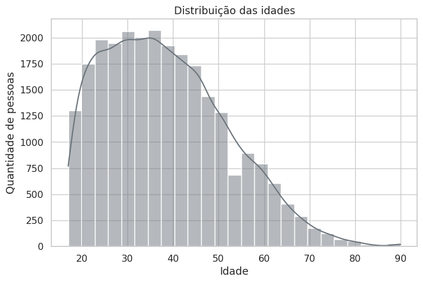

```python
plt.figure(figsize=(8, 5))

sns.histplot(
    data=df_treino,
    x="age",
    bins=25,
    kde=True,
    color=COR_NEUTRA
)

plt.title("Distribuição das idades")
plt.xlabel("Idade")
plt.ylabel("Quantidade de pessoas")
plt.show()
```

### Idade

As barras mais altas ficam na região dos 30 anos. Depois, a frequência diminui e sobra uma cauda à direita, com poucos registros nas idades mais avançadas. Isso complementa o resumo anterior: mesmo com média e mediana próximas, o histograma não é simétrico. O máximo de 90 anos merece atenção, mas a distância em relação ao restante não é, por si só, motivo para excluir o registro.

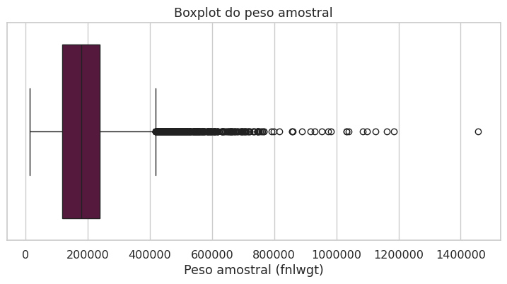

```python
plt.figure(figsize=(9, 4))

sns.boxplot(
    data=df_treino,
    x="fnlwgt",
    color= COR_DESTAQUE
)

plt.title("Boxplot do peso amostral")
plt.xlabel("Peso amostral (fnlwgt)")
plt.ticklabel_format(style="plain", axis="x")
plt.show()
```

### Peso amostral (`fnlwgt`)

A caixa ocupa uma faixa pequena perto dos muitos pontos à direita, e há um registro próximo de 1,45 milhão. Esses pontos ultrapassam a haste superior do boxplot, mas isso não prova que estejam errados. Como `fnlwgt` é um peso amostral, valores altos podem ter uma explicação na construção da base. Vamos mantê-los nesta etapa e usar mediana e intervalo interquartil como referência para o escalonamento.

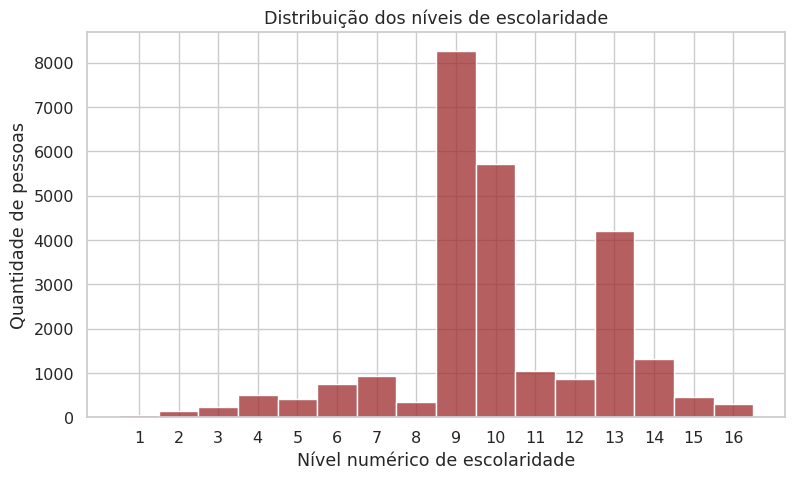

```python
plt.figure(figsize=(9, 5))

sns.histplot(
    data=df_treino,
    x="education.num",
    discrete=True,
    color=COR_PRINCIPAL
)

plt.title("Distribuição dos níveis de escolaridade")
plt.xlabel("Nível numérico de escolaridade")
plt.ylabel("Quantidade de pessoas")
plt.xticks(range(1, 17))
plt.show()
```

### Escolaridade (`education.num`)

O nível 9 se destaca, seguido pelo 10 e pelo 13. A distribuição fica concentrada em alguns códigos, enquanto os extremos têm menos registros. Isso combina com o caráter discreto da coluna: estamos contando níveis de escolaridade, não medindo uma quantidade contínua. Na comparação com a renda, os nomes das categorias vão ajudar a interpretar esses códigos.

## 4. Análise univariada das variáveis categóricas

Vamos comparar a frequência das faixas de renda, dos tipos de trabalho e das ocupações. Nos dois últimos casos, mostramos também os registros sem informação para que eles não desapareçam da contagem.

| income | Quantidade | Percentual (%) |
| --- | --- | --- |
| <=50K | 19367 | 75.93 |
| >50K | 6138 | 24.07 |

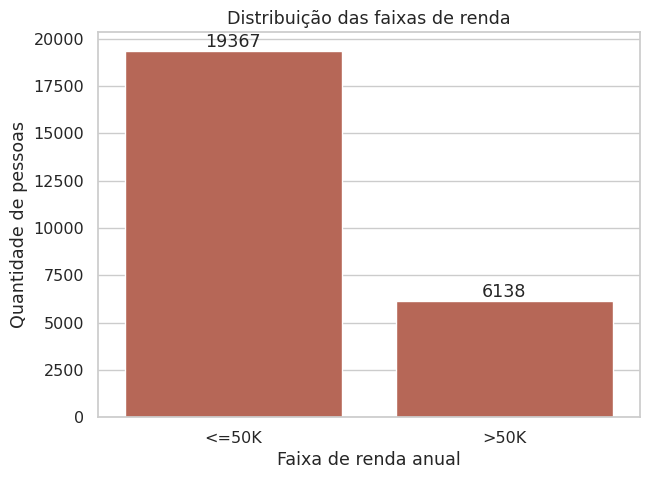

```python
# Frequência das classes de renda
frequencia_income = y_train.value_counts().to_frame(name="Quantidade")
frequencia_income["Percentual (%)"] = (
    y_train.value_counts(normalize=True).mul(100).round(2)
)

display(frequencia_income)

plt.figure(figsize=(7, 5))

ax = sns.countplot(
    data=df_treino,
    x="income",
    order=df_treino["income"].value_counts().index,
    color= COR_SECUNDARIA
)

plt.title("Distribuição das faixas de renda")
plt.xlabel("Faixa de renda anual")
plt.ylabel("Quantidade de pessoas")

# Coloca os valores acima das barras
for container in ax.containers:
    ax.bar_label(container)

plt.show()
```

### Faixa de renda (`income`)

No treino, há 19.367 registros em `<=50K` e 6.138 em `>50K`: aproximadamente três para um. Isso cria uma referência importante para a próxima etapa. Prever sempre a classe mais comum acertaria 75,93% desse conjunto e, ao mesmo tempo, deixaria passar todos os casos de renda acima de 50 mil. Vamos comparar os modelos com essa referência e olhar também precisão e recall da classe `>50K`, além da matriz de confusão.

| workclass | Quantidade | Percentual (%) |
| --- | --- | --- |
| Private | 17829 | 69.90 |
| Self-emp-not-inc | 1967 | 7.71 |
| Local-gov | 1675 | 6.57 |
| Ausente | 1395 | 5.47 |
| State-gov | 1016 | 3.98 |
| Self-emp-inc | 860 | 3.37 |
| Federal-gov | 747 | 2.93 |
| Without-pay | 10 | 0.04 |
| Never-worked | 6 | 0.02 |

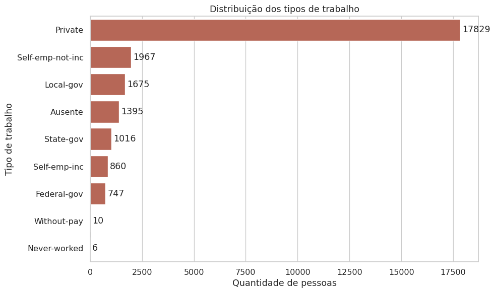

```python
# Criamos uma série temporária para exibir os ausentes no gráfico
workclass_grafico = df_treino["workclass"].fillna("Ausente")

frequencia_workclass = workclass_grafico.value_counts().to_frame(
    name="Quantidade"
)
frequencia_workclass["Percentual (%)"] = (
    workclass_grafico.value_counts(normalize=True).mul(100).round(2)
)

display(frequencia_workclass)

plt.figure(figsize=(10, 6))

ordem_workclass = workclass_grafico.value_counts().index

ax = sns.countplot(
    y=workclass_grafico,
    order=ordem_workclass,
    color= COR_SECUNDARIA
)

plt.title("Distribuição dos tipos de trabalho")
plt.xlabel("Quantidade de pessoas")
plt.ylabel("Tipo de trabalho")

for container in ax.containers:
    ax.bar_label(container, padding=3)

plt.tight_layout()
plt.show()
```

### Tipo de trabalho (`workclass`)

Quase 70% do treino está em `Private`. A segunda categoria, `Self-emp-not-inc`, tem só 7,71%, então a concentração no setor privado é bem marcada nesta amostra.

Os 1.395 registros sem informação correspondem a 5,47% do treino. Vamos preservar essas linhas e indicar a ausência no pré-processamento. No outro extremo da contagem, `Without-pay` e `Never-worked` têm apenas 10 e 6 casos. São categorias válidas, mas há poucos exemplos para aprender ou comparar seus padrões.

| occupation | Quantidade | Percentual (%) |
| --- | --- | --- |
| Craft-repair | 3091 | 12.12 |
| Prof-specialty | 2950 | 11.57 |
| Exec-managerial | 2927 | 11.48 |
| Adm-clerical | 2848 | 11.17 |
| Sales | 2727 | 10.69 |
| Ausente | 2584 | 10.13 |
| Other-service | 2520 | 9.88 |
| Machine-op-inspct | 1507 | 5.91 |
| Transport-moving | 1188 | 4.66 |
| Handlers-cleaners | 1082 | 4.24 |
| Farming-fishing | 751 | 2.94 |
| Tech-support | 696 | 2.73 |
| Protective-serv | 512 | 2.01 |
| Priv-house-serv | 115 | 0.45 |
| Armed-Forces | 7 | 0.03 |

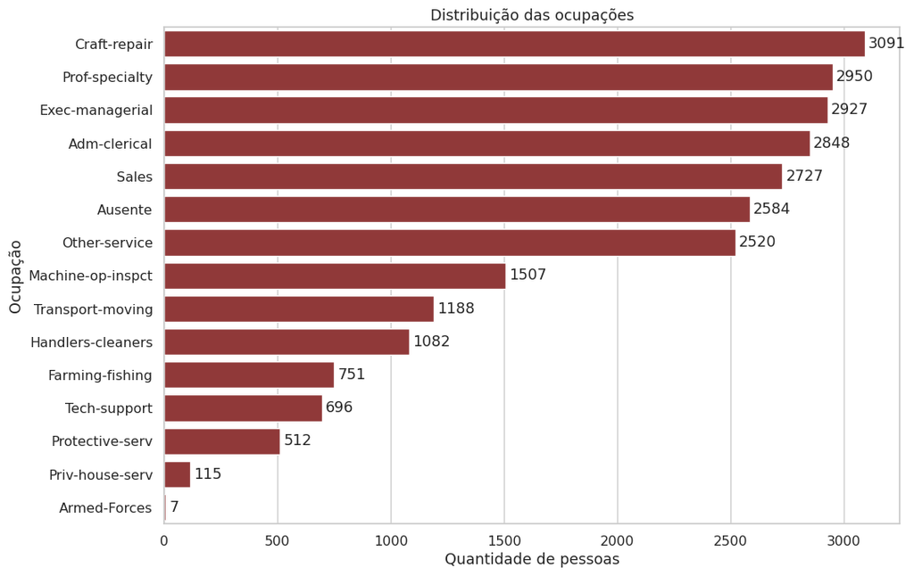

```python
occupation_grafico = df_treino["occupation"].fillna("Ausente")

frequencia_occupation = occupation_grafico.value_counts().to_frame(
    name="Quantidade"
)
frequencia_occupation["Percentual (%)"] = (
    occupation_grafico.value_counts(normalize=True).mul(100).round(2)
)

display(frequencia_occupation)

plt.figure(figsize=(11, 7))

ordem_occupation = occupation_grafico.value_counts().index

ax = sns.countplot(
    y=occupation_grafico,
    order=ordem_occupation,
    color=COR_PRINCIPAL
)

plt.title("Distribuição das ocupações")
plt.xlabel("Quantidade de pessoas")
plt.ylabel("Ocupação")

for container in ax.containers:
    ax.bar_label(container, padding=3)

plt.tight_layout()
plt.show()
```

### Ocupação (`occupation`)

Aqui não há uma categoria dominante como em `workclass`: `Craft-repair`, `Prof-specialty` e `Exec-managerial` ficam próximas, com cerca de 11% a 12% cada.

A falta de informação é quase tão frequente quanto essas ocupações: são 2.584 registros, ou 10,13% do treino. Excluir todos eles reduziria bastante a base, então vamos manter uma categoria própria para a ausência. Já os 7 casos de `Armed-Forces` exigem cuidado nas comparações: poucos registros podem produzir percentuais que parecem muito definitivos.

## 5. Análise bivariada e multivariada

Agora queremos saber o que muda quando olhamos as variáveis em conjunto. Começamos pela correlação de Pearson entre as três colunas numéricas e depois comparamos os gráficos por faixa de renda. A matriz resume relações lineares; ela não esgota os padrões que podem existir nos dados.

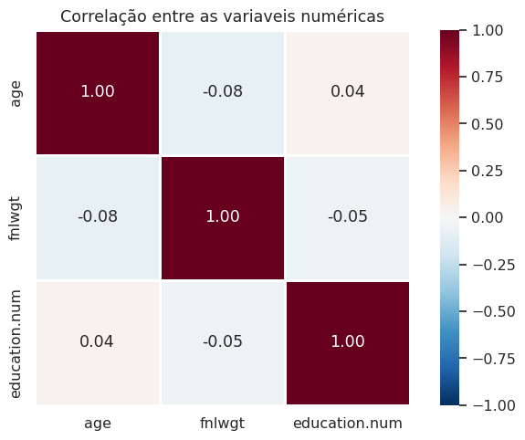

```python
correlacoes = df_treino[colunas_numericas].corr()

plt.figure(figsize=(7, 5))

sns.heatmap(
    correlacoes,
    annot=True,
    fmt=".2f",
    cmap="RdBu_r",
    vmin=-1,
    vmax=1,
    center=0,
    square=True,
    linewidths=0.8
)

plt.title("Correlação entre as variaveis numéricas")
plt.tight_layout()
plt.show()
```

### Matriz de correlação

Nenhum dos três pares apresenta correlação linear forte: idade e peso amostral ficam em −0,08; idade e escolaridade, em 0,04; escolaridade e peso, em −0,05. Esses valores não dão motivo para eliminar uma coluna por forte correlação linear com outra.

Também não mostram quais variáveis ajudam a prever renda, porque `income` nem entra nessa matriz. Para investigar isso, vamos distinguir as classes nos gráficos seguintes. No caso da escolaridade, vale lembrar que Pearson usa as distâncias numéricas entre os códigos.

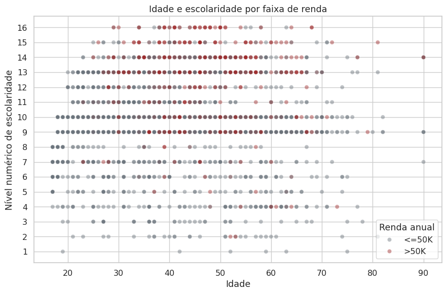

```python
# Usamos uma amostra para evitar muita sobreposição de pontos
amostra_scatter = df_treino.sample(
    n=4000,
    random_state=42
)

plt.figure(figsize=(9, 6))

sns.scatterplot(
    data=amostra_scatter,
    x="age",
    y="education.num",
    hue="income",
    palette={
        "<=50K": COR_NEUTRA,
        ">50K": COR_PRINCIPAL
    },
    alpha=0.45,
    s=35
)

plt.title("Idade e escolaridade por faixa de renda")
plt.xlabel("Idade")
plt.ylabel("Nível numérico de escolaridade")
plt.yticks(range(1, 17))
plt.legend(title="Renda anual")
plt.tight_layout()
plt.show()
```

### Idade, escolaridade e renda

Na amostra de 4.000 registros, os pontos vermelhos ficam mais visíveis nos níveis altos de escolaridade e entre cerca de 30 e 60 anos. Nas idades menores, aparecem mais pontos cinza. Ainda assim, várias combinações de idade e escolaridade têm registros das duas faixas de renda.

A sobreposição de pontos dificulta comparar proporções só pela cor. Por isso, esse gráfico serve como uma primeira pista; as tabelas de percentuais por escolaridade vão permitir uma comparação mais direta.

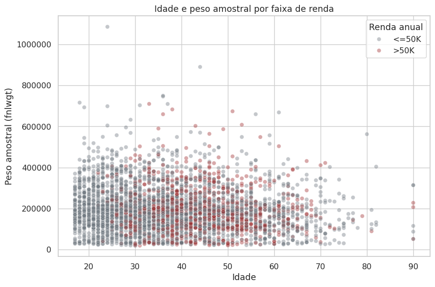

```python
plt.figure(figsize=(9, 6))

sns.scatterplot(
    data=amostra_scatter,
    x="age",
    y="fnlwgt",
    hue="income",
    palette={
        "<=50K": COR_NEUTRA,
        ">50K": COR_PRINCIPAL
    },
    alpha=0.40,
    s=35
)

plt.title("Idade e peso amostral por faixa de renda")
plt.xlabel("Idade")
plt.ylabel("Peso amostral (fnlwgt)")
plt.ticklabel_format(style="plain", axis="y")
plt.legend(title="Renda anual")
plt.tight_layout()
plt.show()
```

### Idade, peso amostral e renda

Trocar escolaridade por `fnlwgt` deixa as duas cores bastante misturadas. Não aparece uma faixa de peso amostral que reúna apenas uma das classes, nem uma tendência linear forte com a idade. Isso é compatível com a correlação de −0,08. Por esse gráfico, não temos uma evidência clara de separação pela variável; sua utilidade em conjunto com outras características ainda precisará ser testada.

### Comparação da renda dentro das categorias

Vamos usar percentuais calculados separadamente em cada categoria. Assim, a pergunta passa a ser “qual parcela deste grupo ganha mais de 50 mil?”, em vez de comparar apenas quantidades de grupos com tamanhos diferentes. As contagens continuam importantes para interpretar categorias pequenas.

| income education | <=50K | >50K |
| --- | --- | --- |
| Preschool | 100.00 | 0.00 |
| 1st-4th | 96.18 | 3.82 |
| 5th-6th | 96.65 | 3.35 |
| 7th-8th | 94.35 | 5.65 |
| 9th | 95.18 | 4.82 |
| 10th | 92.98 | 7.02 |
| 11th | 94.74 | 5.26 |
| 12th | 93.02 | 6.98 |
| HS-grad | 83.90 | 16.10 |
| Some-college | 81.01 | 18.99 |
| Assoc-voc | 73.38 | 26.62 |
| Assoc-acdm | 75.62 | 24.38 |
| Bachelors | 58.63 | 41.37 |
| Masters | 43.84 | 56.16 |
| Prof-school | 25.39 | 74.61 |
| Doctorate | 22.74 | 77.26 |

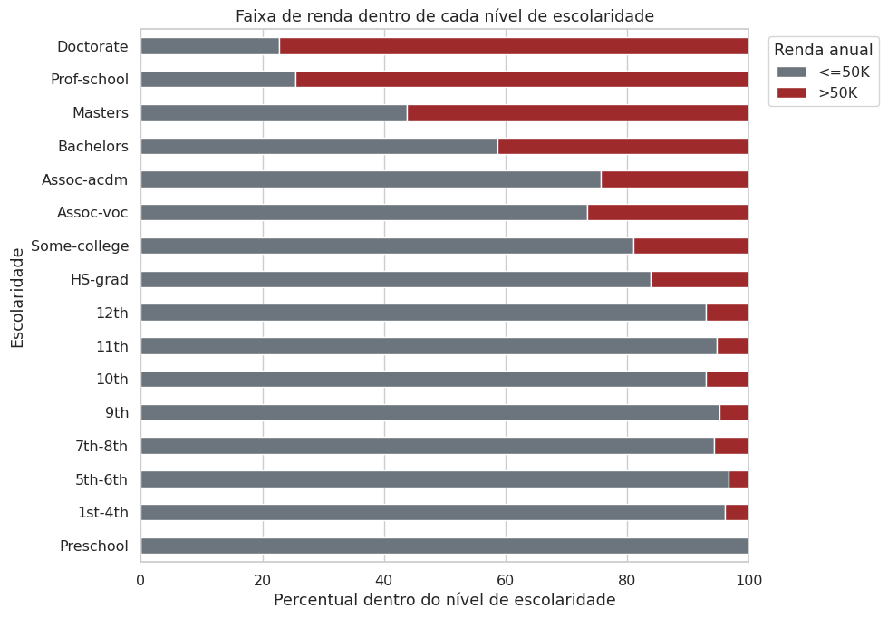

```python
# Ordem dos níveis de escolaridade, do menor para o maior
ordem_educacao = (
    df_treino.groupby("education")["education.num"]
    .median()
    .sort_values()
    .index
)

# Percentual de cada faixa de renda dentro de cada nível
tabela_educacao_renda = pd.crosstab(
    df_treino["education"],
    df_treino["income"],
    normalize="index"
).mul(100)

tabela_educacao_renda = tabela_educacao_renda.loc[ordem_educacao]

display(tabela_educacao_renda.round(2))

ax = tabela_educacao_renda.plot(
    kind="barh",
    stacked=True,
    figsize=(10, 7),
    color=[COR_NEUTRA, COR_PRINCIPAL]
)

plt.title("Faixa de renda dentro de cada nível de escolaridade")
plt.xlabel("Percentual dentro do nível de escolaridade")
plt.ylabel("Escolaridade")
plt.legend(title="Renda anual", bbox_to_anchor=(1.02, 1))
plt.xlim(0, 100)
plt.tight_layout()
plt.show()
```

### Escolaridade e faixa de renda

A diferença entre alguns níveis é grande: em `HS-grad`, 16,10% dos registros estão acima de 50 mil; em `Bachelors`, são 41,37%; e em `Masters`, 56,16%. Os percentuais chegam a 74,61% em `Prof-school` e 77,26% em `Doctorate`.

Existe uma tendência geral de maior proporção de renda alta nos níveis mais altos, mas ela não aumenta a cada degrau: `Assoc-voc`, por exemplo, tem percentual maior que `Assoc-acdm`. A escolaridade parece uma candidata relevante para a classificação. Essa comparação, porém, não isola seu efeito de idade, ocupação ou outras características das pessoas.

| income occupation | <=50K | >50K |
| --- | --- | --- |
| Armed-Forces | 100.00 | 0.00 |
| Priv-house-serv | 99.13 | 0.87 |
| Other-service | 95.83 | 4.17 |
| Handlers-cleaners | 94.18 | 5.82 |
| Farming-fishing | 90.41 | 9.59 |
| Machine-op-inspct | 87.79 | 12.21 |
| Adm-clerical | 87.08 | 12.92 |
| Transport-moving | 81.23 | 18.77 |
| Craft-repair | 78.49 | 21.51 |
| Sales | 74.18 | 25.82 |
| Tech-support | 70.98 | 29.02 |
| Ausente | 69.89 | 30.11 |
| Protective-serv | 68.36 | 31.64 |
| Prof-specialty | 57.08 | 42.92 |
| Exec-managerial | 54.05 | 45.95 |

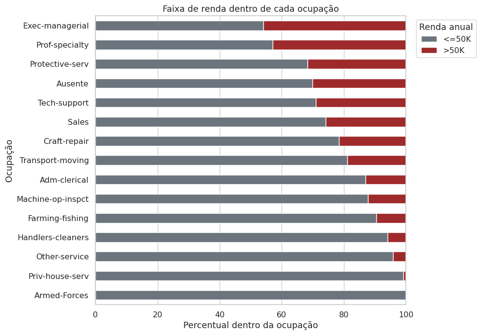

```python
# Cópia temporária para incluir os valores ausentes
ocupacao_renda = df_treino[["occupation", "income"]].copy()
ocupacao_renda["occupation"] = (
    ocupacao_renda["occupation"].fillna("Ausente")
)

tabela_ocupacao_renda = pd.crosstab(
    ocupacao_renda["occupation"],
    ocupacao_renda["income"],
    normalize="index"
).mul(100)

# Ordenação pelo percentual da classe >50K
tabela_ocupacao_renda = tabela_ocupacao_renda.sort_values(">50K")

display(tabela_ocupacao_renda.round(2))

ax = tabela_ocupacao_renda.plot(
    kind="barh",
    stacked=True,
    figsize=(10, 7),
    color=[COR_NEUTRA, COR_PRINCIPAL]
)

plt.title("Faixa de renda dentro de cada ocupação")
plt.xlabel("Percentual dentro da ocupação")
plt.ylabel("Ocupação")
plt.legend(title="Renda anual", bbox_to_anchor=(1.02, 1))
plt.xlim(0, 100)
plt.tight_layout()
plt.show()
```

### Ocupação e faixa de renda

Em `Exec-managerial` e `Prof-specialty`, a proporção de renda acima de 50 mil fica em 45,95% e 42,92%. Em `Other-service`, ela é de 4,17%. Portanto, a composição das faixas de renda muda bastante entre essas ocupações.

Entre os registros sem ocupação informada, 30,11% estão em `>50K`, acima dos 24,07% do treino inteiro. Vale preservar essa ausência como categoria e investigar sua origem; a diferença não prova, sozinha, que ela vai melhorar o modelo.

O zero de `Armed-Forces` precisa ser lido junto com a contagem: são apenas 7 casos. Ele descreve esses registros, sem sustentar uma conclusão geral sobre a ocupação.

| income sex | <=50K | >50K |
| --- | --- | --- |
| Female | 89.14 | 10.86 |
| Male | 69.37 | 30.63 |

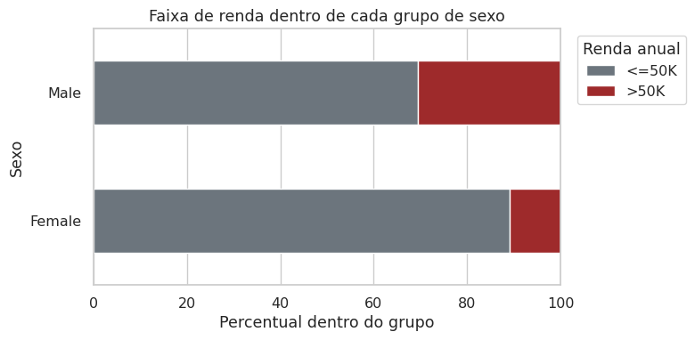

```python
tabela_sexo_renda = pd.crosstab(
    df_treino["sex"],
    df_treino["income"],
    normalize="index"
).mul(100)

display(tabela_sexo_renda.round(2))

ax = tabela_sexo_renda.plot(
    kind="barh",
    stacked=True,
    figsize=(8, 4),
    color=[COR_NEUTRA, COR_PRINCIPAL]
)

plt.title("Faixa de renda dentro de cada grupo de sexo")
plt.xlabel("Percentual dentro do grupo")
plt.ylabel("Sexo")
plt.legend(title="Renda anual", bbox_to_anchor=(1.02, 1))
plt.xlim(0, 100)
plt.tight_layout()
plt.show()
```

### Sexo e faixa de renda

A proporção de `>50K` é de 10,86% em `Female` e 30,63% em `Male`, uma diferença de 19,77 pontos percentuais no treino. A tabela mostra a diferença entre os grupos, mas não explica sua origem: não estamos controlando escolaridade, ocupação ou outras características.

Como `sex` está incluída entre as entradas do pré-processamento, na modelagem será necessário comparar os erros por grupo e avaliar essa escolha. Encontrar uma associação com a renda não basta para concluir que usar a variável seja adequado.

### Distribuições numéricas por faixa de renda

Os boxplots abaixo permitem comparar medianas e intervalos centrais sem a sobreposição dos gráficos de dispersão. Vamos observar idade, escolaridade e peso amostral em cada classe.

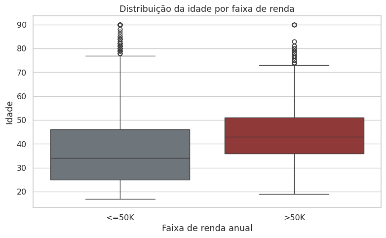

```python
plt.figure(figsize=(8, 5))

sns.boxplot(
    data=df_treino,
    x="income",
    y="age",
    hue="income",
    order=["<=50K", ">50K"],
    palette={
        "<=50K": COR_NEUTRA,
        ">50K": COR_PRINCIPAL
    },
    legend=False
)

plt.title("Distribuição da idade por faixa de renda")
plt.xlabel("Faixa de renda anual")
plt.ylabel("Idade")
plt.tight_layout()
plt.show()
```

### Idade e faixa de renda

A mediana passa de aproximadamente 34 anos em `<=50K` para 43 em `>50K`. O grupo de renda mais alta tem a parte central da distribuição deslocada para idades maiores, mas há bastante sobreposição entre as caixas. A diferença descreve uma tendência do grupo, sem definir a faixa de renda de alguém pela idade.

Os pontos acima das hastes serão mantidos: o critério do boxplot destaca idades pouco frequentes, mas não identifica erros de cadastro.

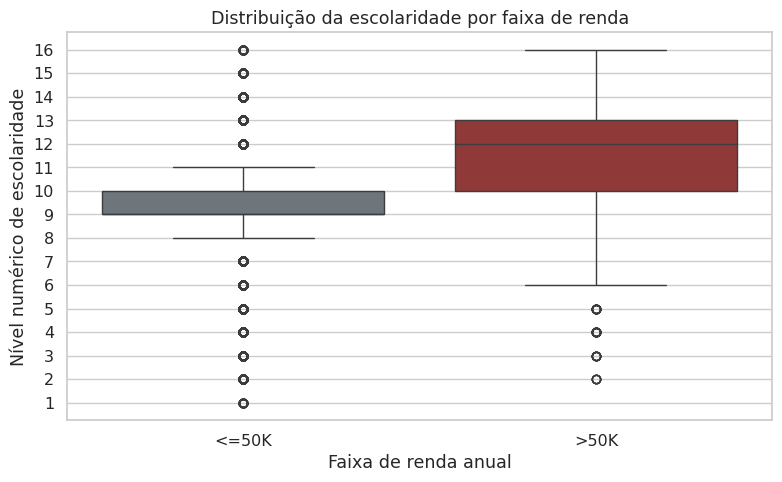

```python
plt.figure(figsize=(8, 5))

sns.boxplot(
    data=df_treino,
    x="income",
    y="education.num",
    hue="income",
    order=["<=50K", ">50K"],
    palette={
        "<=50K": COR_NEUTRA,
        ">50K": COR_PRINCIPAL
    },
    legend=False
)

plt.title("Distribuição da escolaridade por faixa de renda")
plt.xlabel("Faixa de renda anual")
plt.ylabel("Nível numérico de escolaridade")
plt.yticks(range(1, 17))
plt.tight_layout()
plt.show()
```

### Escolaridade e faixa de renda

Os pontos isolados não indicam necessariamente um problema. Como a caixa de `<=50K` é estreita, vários níveis válidos acabam marcados como extremos pela regra do boxplot. Excluí-los apagaria justamente parte da diversidade de escolaridade dentro dessa faixa de renda.

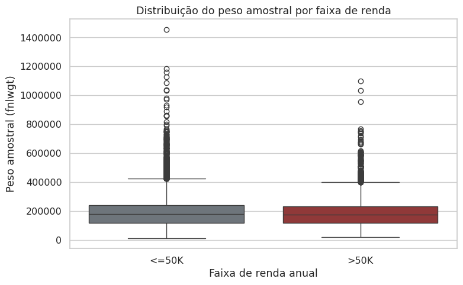

```python
plt.figure(figsize=(8, 5))

sns.boxplot(
    data=df_treino,
    x="income",
    y="fnlwgt",
    hue="income",
    order=["<=50K", ">50K"],
    palette={
        "<=50K": COR_NEUTRA,
        ">50K": COR_PRINCIPAL
    },
    legend=False
)

plt.title("Distribuição do peso amostral por faixa de renda")
plt.xlabel("Faixa de renda anual")
plt.ylabel("Peso amostral (fnlwgt)")
plt.ticklabel_format(style="plain", axis="y")
plt.tight_layout()
plt.show()
```

### Peso amostral e faixa de renda

As caixas de `fnlwgt` são muito parecidas: as medianas ficam próximas e os intervalos centrais se sobrepõem. Os valores altos aparecem nas duas classes. Esse resumo não sugere uma diferença marcante de peso amostral entre as faixas de renda.

Por enquanto, a coluna permanece como entrada, mas vale comparar modelos com e sem ela usando apenas os dados de treino. Incluir `fnlwgt` como atributo não equivale a ponderar as observações pelo peso amostral. As contagens e os percentuais apresentados aqui são dos registros da base, sem essa ponderação.

## 6. Escolhas de pré-processamento

A exploração levou às seguintes escolhas iniciais:

- **Ausências:** usar `Ausente` nas colunas categóricas, preservando principalmente os muitos casos sem ocupação. A imputação numérica pela mediana fica preparada, embora não tenham aparecido nulos nessas três colunas.
- **Escala:** usar `RobustScaler` nas numéricas. Ele centraliza pela mediana e escala pelo intervalo interquartil. Essas referências são menos sensíveis a extremos, mas os valores altos continuam na base: o método não remove outliers nem garante que deixem de afetar o modelo.
- **Categorias:** aplicar one-hot encoding, sem atribuir uma ordem artificial a ocupação, estado civil ou tipo de trabalho. Com `handle_unknown="ignore"`, uma categoria nova não interrompe a transformação; ela fica com zeros nas colunas correspondentes àquela variável.
- **Escolaridade:** manter inicialmente `education.num` e retirar `education`, para não representar duas vezes o mesmo conceito. Essa escolha é simples, mas usa distâncias numéricas entre níveis; na modelagem, vale comparar com uma representação categórica.

O código ajusta o pré-processador no treino e aplica essas regras ao teste. Se usarmos validação cruzada depois, o pré-processamento deverá ficar dentro do pipeline do modelo e ser ajustado novamente em cada divisão de treino.

```python
from sklearn.compose import ColumnTransformer
from sklearn.pipeline import Pipeline
from sklearn.impute import SimpleImputer
from sklearn.preprocessing import OneHotEncoder, RobustScaler

# Retiramos education porque ela repete a informação de education.num
X_train_modelo = X_train.drop(columns=["education"]).copy()
X_test_modelo = X_test.drop(columns=["education"]).copy()

colunas_numericas_modelo = [
    "age",
    "fnlwgt",
    "education.num"
]

colunas_categoricas_modelo = [
    coluna
    for coluna in X_train_modelo.columns
    if coluna not in colunas_numericas_modelo
]

pipeline_numerico = Pipeline([
    (
        "imputacao",
        SimpleImputer(strategy="median")
    ),
    (
        "escala",
        RobustScaler()
    )
])

pipeline_categorico = Pipeline([
    (
        "imputacao",
        SimpleImputer(
            strategy="constant",
            fill_value="Ausente"
        )
    ),
    (
        "one_hot",
        OneHotEncoder(
            handle_unknown="ignore",
            sparse_output=False
        )
    )
])

preprocessador = ColumnTransformer([
    (
        "numericas",
        pipeline_numerico,
        colunas_numericas_modelo
    ),
    (
        "categoricas",
        pipeline_categorico,
        colunas_categoricas_modelo
    )
])

# O fit é feito apenas no treino
X_train_preparado = preprocessador.fit_transform(X_train_modelo)

# O teste recebe as regras aprendidas no treino
X_test_preparado = preprocessador.transform(X_test_modelo)

print("Formato original do treino:", X_train_modelo.shape)
print("Formato após o pré-processamento:", X_train_preparado.shape)
print("Formato do teste preparado:", X_test_preparado.shape)
print("Valores ausentes após o pipeline:", np.isnan(X_train_preparado).sum())
```

```
Formato original do treino: (25505, 10)
Formato após o pré-processamento: (25505, 89)
Formato do teste preparado: (6377, 89)
Valores ausentes após o pipeline: 0
```

### Resultado do pré-processamento

Depois de retirar `education`, o treino tinha 10 colunas. Com a abertura das categorias em colunas binárias, passou a ter 89; o teste recebeu as mesmas 89 colunas. No código, isso é feito com `fit_transform` no treino e apenas `transform` no teste.

A checagem exibida encontrou zero valores ausentes no treino transformado. Ela ainda não verifica os ausentes do teste, nem demonstra que essa seja a melhor preparação para todos os modelos.

## 7. Redução de dimensionalidade com PCA

Vamos projetar as três variáveis numéricas em duas componentes para visualizar uma versão resumida dos dados. Usamos as colunas já transformadas pelo pipeline numérico. As categorias codificadas nas outras colunas não participam deste PCA.

O PCA procura direções de maior variância, sem usar a renda para escolher essas direções. As cores serão acrescentadas depois, apenas para comparar as classes na projeção. O escalonamento por mediana e intervalo interquartil não torna o PCA imune aos valores extremos.

O PCA foi utilizado nesta etapa como ferramenta exploratória de visualização e não foi incorporado ao pipeline; na APS2, sua inclusão como transformação poderá ser comparada empiricamente com o uso das variáveis numéricas originais.

```
Variância explicada:
```

|  | Componente | Variância explicada (%) |
| --- | --- | --- |
| 0 | Componente 1 | 39.95 |
| 1 | Componente 2 | 35.17 |

```
Peso das variáveis em cada componente:
```

|  | Componente 1 | Componente 2 |
| --- | --- | --- |
| age | -0.187 | -0.012 |
| fnlwgt | 0.862 | 0.478 |
| education.num | -0.471 | 0.878 |

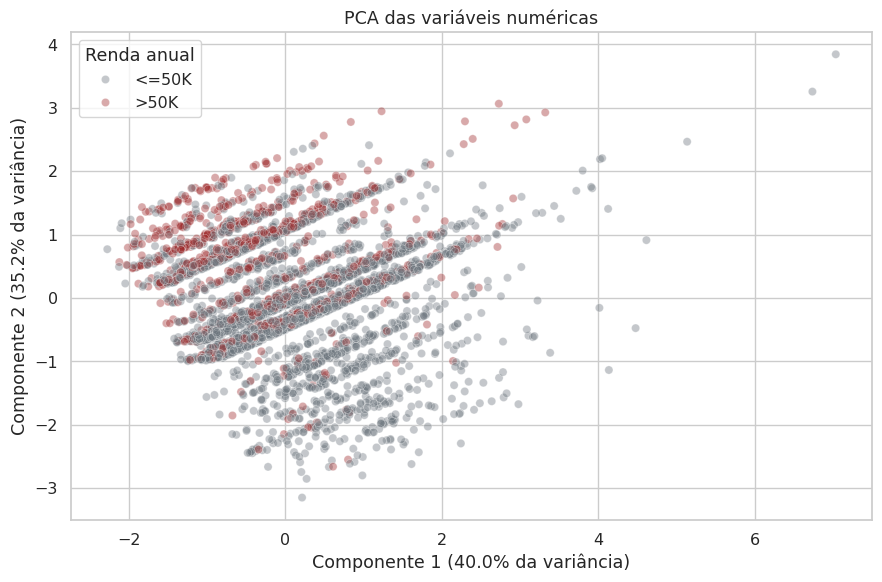

```python
from sklearn.decomposition import PCA

# Recupera o pipeline numérico já ajustado no treino
transformador_numerico = (
    preprocessador.named_transformers_["numericas"]
)

X_numerico_preparado = transformador_numerico.transform(
    X_train_modelo[colunas_numericas_modelo]
)

# Redução de três variáveis para duas componentes
pca = PCA(n_components=2)
componentes_pca = pca.fit_transform(X_numerico_preparado)

df_pca = pd.DataFrame(
    componentes_pca,
    columns=["Componente 1", "Componente 2"]
)

df_pca["income"] = y_train.reset_index(drop=True)

variancia_pca = pd.DataFrame({
    "Componente": ["Componente 1", "Componente 2"],
    "Variância explicada (%)": (
        pca.explained_variance_ratio_ * 100
    ).round(2)
})

cargas_pca = pd.DataFrame(
    pca.components_.T,
    index=colunas_numericas_modelo,
    columns=["Componente 1", "Componente 2"]
).round(3)

print("Variância explicada:")
display(variancia_pca)

print("Peso das variáveis em cada componente:")
display(cargas_pca)

# Amostra usada somente para deixar o gráfico mais legível
amostra_pca = df_pca.sample(
    n=5000,
    random_state=42
)

plt.figure(figsize=(9, 6))

sns.scatterplot(
    data=amostra_pca,
    x="Componente 1",
    y="Componente 2",
    hue="income",
    hue_order=["<=50K", ">50K"],
    palette={
        "<=50K": COR_NEUTRA,
        ">50K": COR_PRINCIPAL
    },
    alpha=0.40,
    s=35
)

plt.title("PCA das variáveis numéricas")
plt.xlabel(
    f"Componente 1 "
    f"({pca.explained_variance_ratio_[0] * 100:.1f}% da variância)"
)
plt.ylabel(
    f"Componente 2 "
    f"({pca.explained_variance_ratio_[1] * 100:.1f}% da variância)"
)
plt.legend(title="Renda anual")
plt.tight_layout()
plt.show()
```

### O que o PCA mostrou

As duas componentes explicam 39,95% e 35,17% da variância, somando 75,12% da variância das três colunas numéricas após o pré-processamento. Isso não significa preservar 75,12% da informação necessária para prever renda.

Na primeira componente, o maior coeficiente em valor absoluto é o de `fnlwgt` (0,862), seguido por `education.num` (−0,471). Na segunda, a escolaridade tem coeficiente 0,878 e o peso amostral, 0,478. A idade tem coeficientes menores nessas duas direções, o que não mede sua importância para um classificador.

Na amostra de 5.000 pontos usada no gráfico, o vermelho aparece mais na parte superior, mas continua misturado ao cinza. Não há uma separação clara nessa projeção. Ainda assim, perder essa separação em duas componentes não prova que as três variáveis originais sejam insuficientes para um modelo: o PCA resume variância, não busca a melhor fronteira entre as classes.

## 8. Conclusão

A primeira dificuldade apareceu antes dos gráficos: a base não tinha nulos reconhecidos pelo Pandas, mas usava `?` e `occupation` como valores que precisavam de tratamento. Depois da limpeza, a falta de ocupação ainda atingia cerca de um em cada dez registros do treino. Mantivemos essas linhas e representamos a ausência no pré-processamento.

Nas comparações de renda, a escolaridade trouxe um contraste claro: a proporção acima de 50 mil foi de 16,10% em `HS-grad` para 41,37% em `Bachelors` e 56,16% em `Masters`. As ocupações também apresentaram diferenças, e a mediana de idade foi maior na faixa de renda alta. Esses resultados orientam os próximos testes, mas ainda não demonstram quais variáveis terão maior importância no modelo.

O desbalanceamento também vai pesar na avaliação: prever sempre `<=50K` já acertaria cerca de 76% do treino. Precisamos verificar se o classificador consegue identificar `>50K`, e não apenas repetir a classe mais comum. Como o pré-processamento inclui `sex`, também será necessário observar os erros por grupo.

Temos uma preparação inicial com 89 colunas e uma projeção por PCA que resume 75,12% da variância das três numéricas transformadas. Na APS2, vamos testar essas escolhas dentro da validação de treino, incluindo a representação da escolaridade e a presença de `fnlwgt`, antes de fazer a avaliação final no teste.

## 9. Referências

- GÉRON, Aurélien. **Hands-On Machine Learning with Scikit-Learn, Keras, and TensorFlow**. 3. ed. Sebastopol: O’Reilly Media, 2022.
- INSPER. **Análise Exploratória de Dados**. Machine Learning, 2026. Disponível em: https://insper.github.io/ML/pt/2026.2/classes/eda/. Acesso em: 12 set. 2026.
- INSPER. **Pré-processamento de Dados**. Machine Learning, 2026. Disponível em: https://insper.github.io/ML/pt/2026.2/classes/preprocessing/. Acesso em: 12 set. 2026.
- INSPER. **Pipelines**. Machine Learning, 2026. Disponível em: https://insper.github.io/ML/pt/2026.2/classes/pipelines/. Acesso em: 12 set. 2026.
- INSPER. **Redução de Dimensionalidade**. Machine Learning, 2026. Disponível em: https://insper.github.io/ML/pt/2026.2/classes/dimensionality-reduction/. Acesso em: 12 set. 2026.
- KAGGLE. **Adult Income Census**. Disponível em: https://www.kaggle.com/datasets/anaghakp/adult-income-census. Acesso em: 12 set. 2026.

Materiais de apoio para as escolhas metodológicas:

- INSPER. [Referências da disciplina de Machine Learning](https://insper.github.io/ML/pt/references/). A página reúne livros-texto e documentação das bibliotecas utilizadas.
- SCIKIT-LEARN. [RobustScaler](https://scikit-learn.org/stable/modules/generated/sklearn.preprocessing.RobustScaler.html) e [PCA](https://scikit-learn.org/stable/modules/generated/sklearn.decomposition.PCA.html). Documentação consultada para conferir o escalonamento e a interpretação da variância explicada.